# Classifying Movie Genres Based on the Title and Plot

Cameron Wonchoba

Andrew Leo

Tou Yang

# Overview

Movies are put into categories called `genres`. These genres describe the expectations that a person should have when they watch the movie.

We are given a data set that maps each movie title and their plot to the genre they are in. Using Natural Language Processing, we will identify what genre the movie is based on the title and plot.

Developing a tool that can accurately identify these genres based on the genre and plot may help movie creators effectively write a movie title and generic plot. Once they create their title and plot, they could pass it into this model and verify that it conveys the message that they intend.

This is a multiclass classification problem that will utilize Natural Language Processing.

## What is Natural Language Processing?

Natural Language processing allows computers to analyze and understand human written language. Ultimately, we want to be able to parse the natural language in a way that is valuable.

There are two parts of a language that the computer needs to be able to understand:

### Syntax

Syntax describes the way we arrange words to make a sentence that is grammatically correct. Syntax is important to help the computer learn the structure of our language. It helps to learn if each sentence is grammatically correct or not.

### Semantics

Semantics describes the meaning behind each word, sentence or phrase. Semantics are important to help the computer understand the meaning behind indiviudal words and combination of words. This becomes difficult when words have more than one meaning. For example:

1. I crashed my car.
2. I crashed on my couch.

Here, the word "crashed" have different meanings.

In the first example, "crashed" means destroyed or ruined.

In the second example, "crashed" means sleep.

Helping a computer understand these subtle differences in meaning can be difficult to do.

## Techniques/Libraries to Used in NLP

Below is a list of libraries and tools that may help us in the project.

1. Natural Language Toolkit (NLTK)
   - https://www.nltk.org/
   - Slow and steep learning curve
2. TextBlob
   - https://textblob.readthedocs.io/en/dev/
   - Easy to learn (great for beginners!), but it is slow
3. CoreNLP
   - https://stanfordnlp.github.io/CoreNLP/
   - Really fast and can be integrated with NLTK
4. Gensim
   - https://github.com/RaRe-Technologies/gensim
   - Specializes in semantic recognition
5. spaCy
   - https://spacy.io/
   - Really fast! Only supports 7 languages (Python is one of them, so we're good).
6. polyglot
   - https://polyglot.readthedocs.io/en/latest/index.html
   - Similar performance to spaCy but supports more languages.
7. scikit–learn
   - https://scikit-learn.org/stable/
   - Great documentation and familiar. Does not use Neural Networks for processing, so it isn't as good.
8. Pattern
   - https://www.clips.uantwerpen.be/pages/pattern
   - Good for webmining, but doesn't include enough NLP tasks

Sources:

https://becominghuman.ai/a-simple-introduction-to-natural-language-processing-ea66a1747b32

https://sunscrapers.com/blog/8-best-python-natural-language-processing-nlp-libraries/

# Topic Modeling

Here we are going to do a form of topic modeling. Topic Modeling is trying to understand the topic of a piece of text. In our case, the topic can be defined as the genre. We will try to figure out the genre of the movie (topic).

# Data

The data set that we are using can be found here: https://github.com/davidsbatista/text-classification/blob/master/movies_genres.csv.bz2

This data set includes the title, plot and genre of 117,352 movies. The genres that are included in this data set are:

- Action
- Adult
- Adventure
- Animation
- Biography
- Comedy
- Crime
- Documentary
- Drama
- Family
- Fantasy
- Game-Show
- History
- Horror
- Lifestyle
- Music
- Musical
- Mystery
- News
- Reality-TV
- Romance
- Sci-Fi
- Short
- Sport
- Talk-Show
- Thriller
- War
- Western

> NOTE: Each movie is mapped to only one genre. In practice, it may be the case that movies are mapped to more than one genre.

```python
import pandas as pd
import numpy as np
import time
pd.set_option('display.max_columns', None)
```

```python
path_to_data = "../data/movies_genres.csv"
movies = pd.read_csv(path_to_data, delimiter='\t')
```

```python
movies.head(3)
```

|  | title | plot | Action | Adult | Adventure | Animation | Biography | Comedy | Crime | Documentary | Drama | Family | Fantasy | Game-Show | History | Horror | Lifestyle | Music | Musical | Mystery | News | Reality-TV | Romance | Sci-Fi | Short | Sport | Talk-Show | Thriller | War | … |
| --- | --- | --- | --- | --- | --- | --- | --- | --- | --- | --- | --- | --- | --- | --- | --- | --- | --- | --- | --- | --- | --- | --- | --- | --- | --- | --- | --- | --- | --- | --- |
| 0 | "#7DaysLater" (2013) | #7dayslater is an interactive comedy series f... | 0 | 0 | 0 | 0 | 0 | 1 | 0 | 0 | 0 | 0 | 0 | 0 | 0 | 0 | 0 | 0 | 0 | 0 | 0 | 0 | 0 | 0 | 0 | 0 | 0 | 0 | 0 | … |
| 1 | "#BlackLove" (2015) {Crash the Party (#1.9)} | With just one week left in the workshops, the... | 0 | 0 | 0 | 0 | 0 | 0 | 0 | 0 | 0 | 0 | 0 | 0 | 0 | 0 | 0 | 0 | 0 | 0 | 0 | 1 | 0 | 0 | 0 | 0 | 0 | 0 | 0 | … |
| 2 | "#BlackLove" (2015) {Making Lemonade Out of Le... | All of the women start making strides towards... | 0 | 0 | 0 | 0 | 0 | 0 | 0 | 0 | 0 | 0 | 0 | 0 | 0 | 0 | 0 | 0 | 0 | 0 | 0 | 1 | 0 | 0 | 0 | 0 | 0 | 0 | 0 | … |

# Dropping Rows

Some movies and TV shows are mapped to more than one genre. This substantially increases the complexity of our problem, so we decided to drop them.

In the future we would want to doing some analysis with all of the rows. We may want to get a probability of the plot belonging to each genre, and we could grab the top 'x' genres.

```python
def sum_frame_by_column(frame, new_col_name, list_of_cols_to_sum):
    frame[new_col_name] = frame[list_of_cols_to_sum].astype(float).sum(axis=1)
    return(frame)

sum_frame_by_column(movies, 'genre_sum', ['Action','Adult','Adventure','Animation','Biography','Comedy','Crime','Documentary','Drama','Family','Fantasy','Game-Show','History','Horror','Music','Musical','Mystery','News','Reality-TV','Romance','Sci-Fi','Short','Sport','Talk-Show','Thriller','War','Western'])

print("Movie Count prior to dropping rows: ", movies.shape[0])

movies = movies[movies.genre_sum == 1]

print("Movie Count after dropping rows: ", movies.shape[0])
```

```
Movie Count prior to dropping rows:  117352
Movie Count after dropping rows:  47827
```

# Dropping TV rows

Some genres are related to TV. We will drop those rows, as this notebook is focused on finding movie genres

```python
movies = movies[movies['Reality-TV'] != 1]
movies = movies[movies['Talk-Show'] != 1]
movies = movies[movies['News'] != 1]
movies = movies[movies['Game-Show'] != 1]

print("Movie Count after dropping rows: ", movies.shape[0])
```

```
Movie Count after dropping rows:  35035
```

# Convert one-hot-encoded to single row

The target variables need to be condensed down to a single row.

```python
def get_genre(row):
    for c in movies.columns:
        if row[c] == 1:
            return c

movies['Genre'] = movies.apply(get_genre, axis=1)

movies['Genre'].head()
```

```
0    Comedy
5    Comedy
7    Comedy
8    Comedy
9    Sci-Fi
Name: Genre, dtype: object
```

# Exploratory Data Analysis

```python
import nltk
nltk.download('all', quiet=True)
```

```
True
```

## Shape

How many observations and columns do we have?

```python
print(f"There are {movies.shape[0]} rows and {movies.shape[1]} columns.")
```

```
There are 35035 rows and 32 columns.
```

## Which movies do we have more observations for?

```
Comedy         10925
Drama           7467
Documentary     6090
Western         1950
Animation       1663
Family          1611
Music            743
Adventure        703
Sport            693
Crime            638
Romance          524
Sci-Fi           377
History          293
Horror           262
Mystery          240
Action           201
Thriller         178
Biography        164
Fantasy          128
Short             70
Adult             52
Musical           36
War               27
Name: Genre, dtype: int64
```

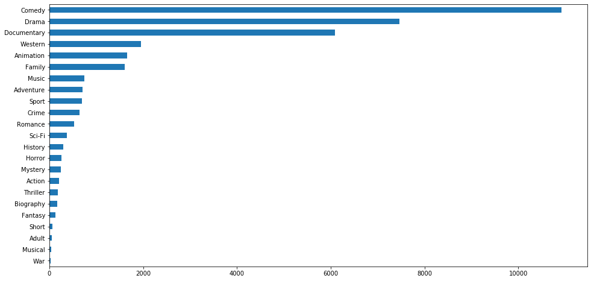

```python
print(movies['Genre'].value_counts())

movies['Genre'].value_counts().sort_values().plot(kind = 'barh', figsize=(16,8))
```

The most common movie genres are:

- Comedy
- Drama
- Documentary
- Western

The least common movie genres are:

- War
- Musical
- Adult
- Short

Another thing to note. Our data is extremely imbalanced.

Are there any weird values in the table?

```python
movies.isnull().any()
```

```
title          False
plot           False
Action         False
Adult          False
Adventure      False
Animation      False
Biography      False
Comedy         False
Crime          False
Documentary    False
Drama          False
Family         False
Fantasy        False
Game-Show      False
History        False
Horror         False
Lifestyle      False
Music          False
Musical        False
Mystery        False
News           False
Reality-TV     False
Romance        False
Sci-Fi         False
Short          False
Sport          False
Talk-Show      False
Thriller       False
War            False
Western        False
genre_sum      False
Genre          False
dtype: bool
```

All values exist

## Lets look at the actual titles and plots

```python
movies['title']
```

```
0                                 "#7DaysLater" (2013)
5                                       "#Cake" (2015)
7                                     "#Elmira" (2014)
8                        "#Hashtag: The Series" (2013)
9                               "#LawstinWoods" (2013)
                              ...
117343       "Öyle Bir Geçer Zaman ki" (2010) {(#1.1)}
117344      "Öyle Bir Geçer Zaman ki" (2010) {(#1.14)}
117345      "Öyle Bir Geçer Zaman ki" (2010) {(#1.16)}
117346       "Öyle Bir Geçer Zaman ki" (2010) {(#1.6)}
117351    "Über Österreich - Juwele des Landes" (2016)
Name: title, Length: 35035, dtype: object
```

Movie titles are surrounded by quotes. We will extract them using the following regular expression:

`"([^"]*)"`

In english, this regular expression can be read as:

Match everything that starts with quotes, contains anything that isn't a quote, followed by zero or more things, followed by a quote.

```python
# Lets extract the title name.
movies['Extracted Title'] = movies['title'].str.extract(r'"([^"]*)"')

# Now remove the first occurence of the '#' from the string.
movies['Extracted Title'] = movies['Extracted Title'].str.replace('#',"",1)
```

The year the title was made is surrounded by paranthesis. We will extract them using the following regular expression:

`\((.*?)\)`

```python
movies['year'] = movies['title'].str.extract(r'\((.*?)\)')
```

It turns out that we also have tv shows in this data set. These can be discovered if there is some text surround by curly braces ({}). We can extract these by using the folloiwng regular expression:

`\{(.*?)\}`

We will then get rid of the episode number (these are defined by paranthesis).

`\(.*\)`

```python
movies['Episode Info'] = movies['title'].str.extract(r'\{(.*?)\}')
movies['Episode Info'] = movies['Episode Info'].str.replace(r"\(.*\)","")
```

# Detecting languages

We should look at what languages we have. We should only deal with the english language for now.

We will detect the language of the plot. We choose the plot because it has the most words, and it is supposed to be grammatically correct. We can assume that they are grammatically correct as they are uploaded onto IMbD.

https://pypi.org/project/langdetect/

```python
from langdetect import detect

# Apply the detect function for every row on the "plot" column.
# NOTE: This takes a while to complete.
movies['Language'] = movies.apply(lambda row : detect(row['plot']), axis=1)
```

```python
movies['Language'].value_counts()
```

```
en    34994
nl       12
de       10
da        8
no        3
it        3
es        2
sl        1
hu        1
fr        1
Name: Language, dtype: int64
```

Here is an example of a `Dutch` plot that was found.

```python
movies[movies['Language'] == 'nl']['plot'][16152]
```

```
' In het CMC komt Cleo de Waard zich voorstellen als de nieuwe directeur van het ziekenhuis. Niet iedereen is blij met haar komst. Ondertussen wordt er hard doorgewerkt door de artsen en verpleegkundigen. Zij moeten het hoofd koel houden in moeilijke situaties en alles doen voor hun patiënten.'
```

There are some non-english movies in this set. Lets drop the rows that aren't english.

```python
# Keep rows that are in english.
movies = movies[movies['Language'] == 'en']

# Reset the index as they are now messed up (due to the removal of rows)
movies = movies.reset_index()

movies['Language'].value_counts()
```

```
en    34994
Name: Language, dtype: int64
```

# Tokenization

Now we need to tokenize all of the words.

We are opting for the `TweetTokenizer` instead of `word_tokenize` because the word_tokenizer doesn't seem to handle apostophe's very well. For example:

Give the word `week's`

- word_tokenizer => ['week',"'s"]
- TweetTokenizer => ["week's"]

```python
from nltk.tokenize import TweetTokenizer

start = time.time()

tokenizer = TweetTokenizer()

# For every plot, split it into its respective tokens.
movies["plot_tokens"] =  movies.apply(lambda row : tokenizer.tokenize(row['plot']), axis=1)

print("Time Elapsed: ", time.time() - start)
```

```
Time Elapsed:  12.257766246795654
```

```python
movies['plot'][0]
```

```
" #7dayslater is an interactive comedy series featuring an ensemble cast of YouTube celebrities. Each week the audience writes the brief via social media for an all-new episode featuring a well-known guest-star. Seven days later that week's episode premieres on TV and across multiple platforms."
```

```python
# Joining each token
"--".join(movies['plot_tokens'][0])
```

```
"#7dayslater--is--an--interactive--comedy--series--featuring--an--ensemble--cast--of--YouTube--celebrities--.--Each--week--the--audience--writes--the--brief--via--social--media--for--an--all-new--episode--featuring--a--well-known--guest-star--.--Seven--days--later--that--week's--episode--premieres--…
```

We now have our tokens for each row.

Lets figure out how many Tokens we have...

```python
# I'm also curious as to how many total tokens we have
plot_tokens_lst = movies["plot_tokens"].tolist()

token_count = 0
for sentence in plot_tokens_lst:
    token_count += len(sentence)

print("Total Number of Tokens: ", token_count)
```

```
Total Number of Tokens:  3679495
```

Lets extract these tokens into a list, and find the 20 most common tokens.

```python
from nltk.probability import FreqDist
fdist = FreqDist()

for sentence in plot_tokens_lst:
    for word in sentence:
        fdist[word.lower()]+=1

fdist.most_common(20)
```

```
[('the', 178590),
 ('.', 167101),
 (',', 145388),
 ('to', 116520),
 ('and', 102615),
 ('a', 96373),
 ('of', 67759),
 ('in', 53773),
 ('is', 51092),
 ('his', 36814),
 ('with', 35458),
 ('her', 34742),
 ('he', 32441),
 ('for', 30514),
 ('that', 28963),
 ('on', 23957),
 ('as', 21001),
 ('she', 20743),
 ('but', 20718),
 ('"', 20493)]
```

Unique Number of tokens?

```python
# How many unique tokens are there?
print(f"There are {len(fdist)} unique tokens.")
```

```
There are 93358 unique tokens.
```

These tokens seem uninformative... Lets clean up the tokens a bit by removing puncutation and stop noises.

# Removing Noise

`Stemming` works by cutting off the ends of the words. However, this doesn't always work. Sometimes it will convert a word into a word that is not technically it's root.

`Lemmatization` will reduces each word to it's "true" root.

However, we also want to remove the noise (ie. stopwords). To do this, we will use the function that was seen in the In Class 11 exercise.

This function prunes out all words that is a `punctuation` or a `stop_word`.

Originally from: https://www.digitalocean.com/community/tutorials/how-to-perform-sentiment-analysis-in-python-3-using-the-natural-language-toolkit-nltk

```python
from nltk.stem.wordnet import WordNetLemmatizer
import re, string
from nltk.tag import pos_tag

def remove_noise(tokens, stop_words = ()):
    cleaned_tokens = []

    for token, tag in pos_tag(tokens):
        token = re.sub('http[s]?://(?:[a-zA-Z]|[0-9]|[$-_@.&+#]|[!*\(\),]|'\
                       '(?:%[0-9a-fA-F][0-9a-fA-F]))+','', token)
        token = re.sub("(@[A-Za-z0-9_]+)","", token)

        if tag.startswith("NN"):
            pos = 'n'
        elif tag.startswith('VB'):
            pos = 'v'
        else:
            pos = 'a'

        lemmatizer = WordNetLemmatizer()
        lem_token = lemmatizer.lemmatize(token, pos)

        if len(lem_token) > 0 and lem_token not in string.punctuation and lem_token.lower() not in stop_words:
            cleaned_tokens.append(lem_token.lower())

    return cleaned_tokens
```

```python
# NOTE: This code block takes about 10 minutes to run.
from nltk.corpus import stopwords

start = time.time()

movies['plot_tokens_cleaned'] = movies.apply(lambda row : remove_noise(row['plot_tokens'], stopwords.words('english')), axis=1)

print("Time Elapsed: ", time.time() - start)
```

```
Time Elapsed:  254.74608445167542
```

## Exploring Tokens after pruning

```python
from nltk.probability import FreqDist
fdist = FreqDist()

for sentence in movies['plot_tokens_cleaned'].tolist():
    for word in sentence:
        fdist[word.lower()]+=1

fdist.most_common(20)
```

```
[('get', 12119),
 ('find', 10065),
 ('go', 9401),
 ('take', 9018),
 ('make', 8912),
 ('new', 7962),
 ('one', 7543),
 ('tell', 6764),
 ('life', 6169),
 ('want', 6092),
 ('try', 5986),
 ('help', 5579),
 ('show', 5575),
 ('come', 5525),
 ('time', 5093),
 ('see', 4995),
 ('back', 4968),
 ('work', 4959),
 ('family', 4779),
 ('friend', 4723)]
```

```python
flat_list = [item for sublist in movies['plot_tokens_cleaned'].tolist() for item in sublist]
print(f"There are {len(flat_list)} tokens.")
print(f"There are {len(set(flat_list))} unique tokens.")
```

```
There are 1859994 tokens.
There are 85833 unique tokens.
```

# Exploring Word Density

We can look at the most common words within each genre.

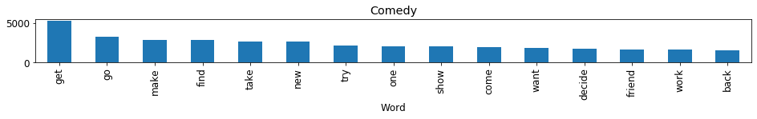

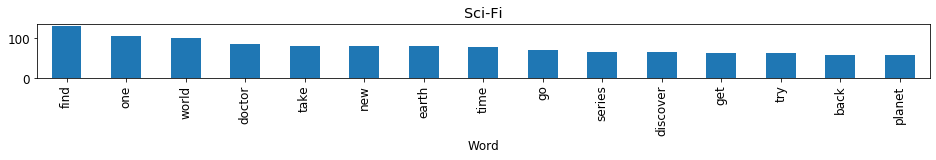

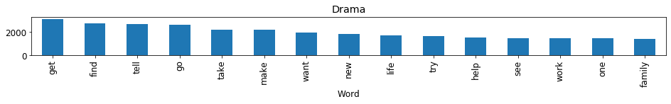

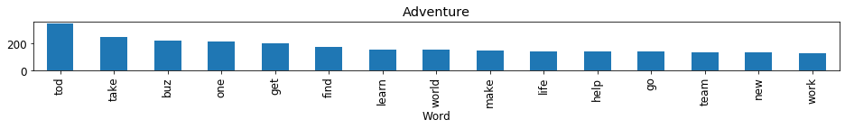

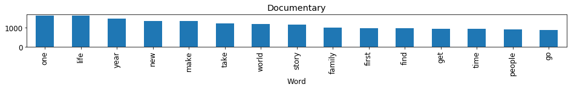

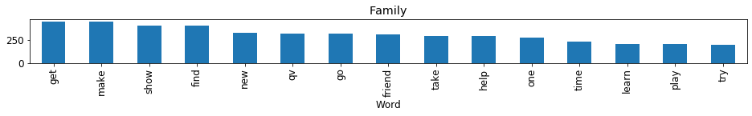

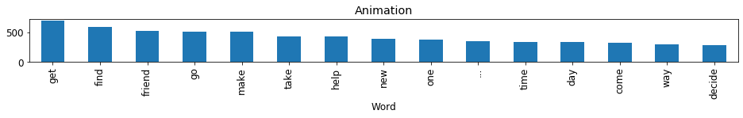

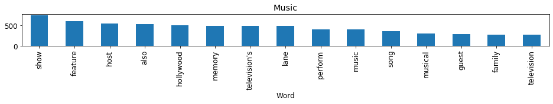

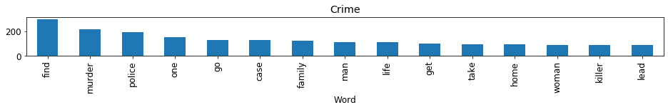

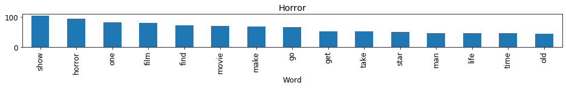

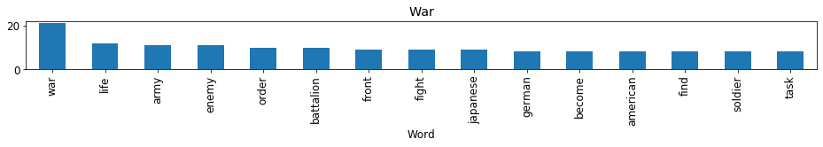

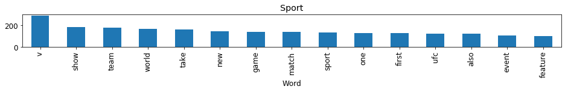

[11 more figures not shown]

```python
from nltk.probability import FreqDist
import matplotlib
from matplotlib import pyplot as plt

def get_all_words(cleaned_tokens_list):
    for tokens in cleaned_tokens_list:
        for token in tokens:
            yield token

# Iterate through each movie and get the most common words. Maybe plot them?
for movie in movies['Genre'].unique():
    all_words = get_all_words(movies[movies[movie] == 1]['plot_tokens_cleaned'].tolist())
    fdist = FreqDist(all_words)

    matplotlib.rcParams.update({'font.size': 12})

    df = pd.DataFrame(fdist.most_common(15),columns=['Word','Count'])
    df.plot(x='Word', y='Count', kind='bar', legend=False, figsize=(16,1))

    plt.title(movie)
    plt.show()
```

We now have a count of the most common words in each genre.

# Sentiment Analysis

We will now look at how positive or negative each plot is.

Using textblob, we are calculating the sentiment polarity of each plot, each of which will lie in the range of [1,-1] where 1 means positive sentiment and -1 means a negative sentiment.

```python
#pip install -U textblob
from textblob import TextBlob

movies['polarity'] = movies['plot'].map(lambda text: TextBlob(text).sentiment.polarity)
movies['plot_len'] = movies['plot'].astype(str).apply(len)

print('5 random Plots with the highest positive sentiment polarity:\n')
pl = movies.loc[movies.polarity == 1, ['plot']].sample(5).values
for p in pl:
    print(p[0],'\n')
    #Only this one takes about 5-15 mins depending on computer
```

```
5 random Plots with the highest positive sentiment polarity:

 The Spotlight shines on "The Impresarios", theatres that reflect the vision and style of the men who built them. These theatres were constructed by legendary showmen like Irving Berlin, David Belasco and Winthrop Ames - men who wanted to leave their mark on Broadway.

 Larry Hartman, is like every wannabe actor pursuing the "Hollywood Dream" until man's best friend steals his audition and takes off with his career! Rejected and out of sorts, Larry is persuaded by his pushy sister Fibi to take advantage of this once in a lifetime meal ticket. Together the three si…

 After battling Yago Jones, Alfredo 'Al' Lambert, and James Foucault, Quentin 'Q' Corder and Nore Davis competed one-on-one for the title 'The Best of Throgs Neck' and the opportunity to represent at the finals against Morris Park. Nore prevailed because of his energy and delivery.

 A trip to Heavenly Valley Ski Resort provides the perfect chance to examine what heaven is like. Who will be there and what can we expect? Discovery Jones heavenly adventure explores God's promise of a perfect eternal place for His children.

 When George accidentally ends up in the Jungle King Afterlife (read: dies), he meets the jungle kings of yesteryear... and immediately starts to feel inadequate. Returning to life, George sets out to prove that he's just as impressive as any of his ancestors!
```

```python
print('5 random Plots with the most neutral sentiment polarity(0):\n')
pl = movies.loc[movies.polarity == 0, ['plot']].sample(5).values
for p in pl:
    print(p[0],'\n')
```

```
5 random Plots with the most neutral sentiment polarity(0):

 Swell gal Junie Butler is sent up river to Marquetta State Prison, landing in the clutches of the hook-handed Matron and her side-kick, prison guard Nancy. Junie impresses her cellmate Vickie with her ukulele song about how she was double crossed.

 After the sudden death of one of Henry's friends Muriel and Iris are concerned that Henry is not carrying enough life insurance. Asking Iris to butt out, he disagrees. Enough coaxing from Muriel changes his mind. But will he pass the physical?

 Llamas take over the streets in Arizona, making for one nerve-racking rodeo. An otter pulls a fast move on a hungry orca. A bull shark takes its chances around a gang of hippopotamuses. There are unlikely foes: a troublemaking dolphin strikes, a sea lion gets revenge on a thresher shark and a heron…

 A tempestuous year in the life of London's Victoria & Albert Museum.

 Whilst trying to evade capture by the Chicago Police Department, Angela takes a bullet in her left arm and requires medical treatment. Just before her laptop battery dies, the Sorcerer tells Angela to seek help from a doctor he knows at Lincolnwood Memorial Hospital in Evanston.
```

```python
print('2 random Plots with the most negative polarity: \n')
pl = movies.loc[movies.polarity == -1, ['plot']].sample(2).values
for p in pl:
    print(pl[0],'\n')
```

```
2 random Plots with the most negative polarity:

[' Michelle Herndon is an anthropology student studying at the University of Florida. Just one month before graduation Michelle takes a stranger under her wing with devastating consequences, leaving friends and family baffled, and their lives shattered.']

[' Michelle Herndon is an anthropology student studying at the University of Florida. Just one month before graduation Michelle takes a stranger under her wing with devastating consequences, leaving friends and family baffled, and their lives shattered.']
```

# Histogram of polarity

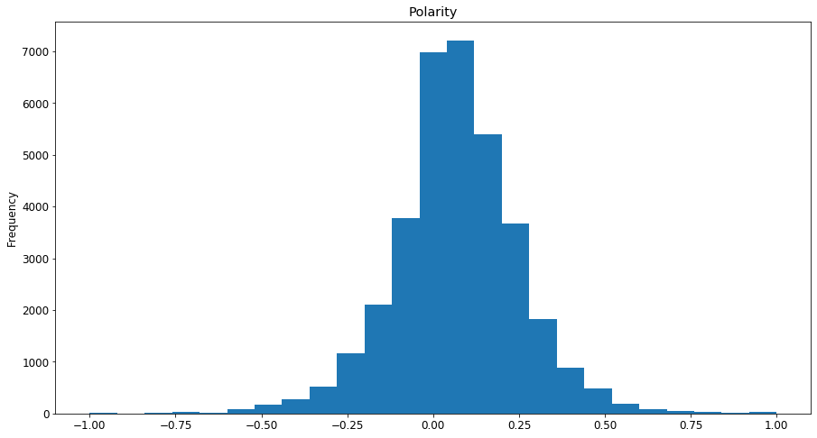

```python
movies['polarity'].plot(
    kind='hist',
    bins = 25,
    legend=False,
    figsize=(15,8))

plt.title('Polarity')

plt.show()
```

Vast majority of the sentiment polarity scores are hovering between -0.25 and 0.25, meaning that most of the plots in the database are more neutral sided. It is safe to say that there are more positive plots and negative plots base on the graph above. As you can see the more we more towards 1 or -1 the less amount of plots we get that have a ploarity score of 1 and -1.

Get the average sentiment for each genre, and plot it. This will show us if different Genres tend to display different sentiments.

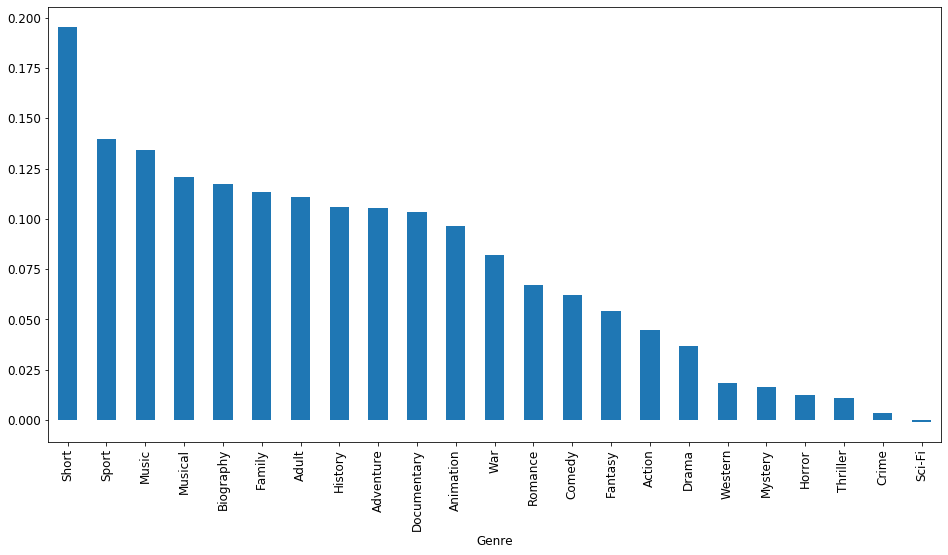

```python
movie_counts_df = movies['Genre'].value_counts().to_frame()

movie_counts_df['Avg Polarity'] = None

movie_counts_df = movie_counts_df.reset_index()

movie_counts_df = movie_counts_df.rename(columns={'Genre':'Count', 'index':'Genre'})

for idx, movie in enumerate(movie_counts_df['Genre']):
    movie_counts_df.loc[idx,'Avg Polarity'] = movies[movies[movie] == 1]['polarity'].mean()

movie_counts_df = movie_counts_df.sort_values('Avg Polarity', ascending=False)
movie_counts_df.plot(x='Genre', y='Avg Polarity', kind='bar', legend=False, figsize= (16,8))
```

Films are generally more positive than not, but some genres have more positive sentiment than others.

Shorts, Sports and music generally have really positive plots while Crimes, Thrillers and Sci-fi tend to have more negative plots.

# Word Clouds

Finally, we wil build word clouds for the frequency of each word. This is useful as people can quickly take a glance at a word cloud to see which words are the most popular for a given genre.

> NOTE: Word Clouds is actually a terrible tool for a Data Scientist. However, they are cool visualizations that allow you to gain a lot of information from a really quick glance. Additionally, buisness professionals like cool visualizations like these.

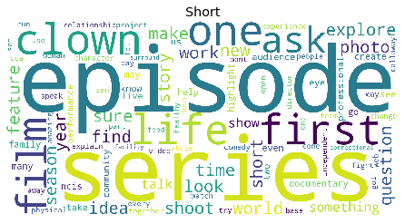

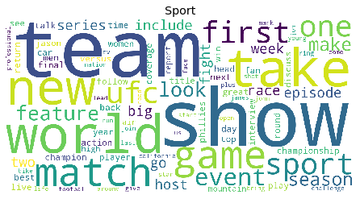

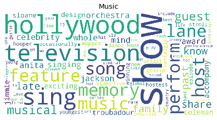

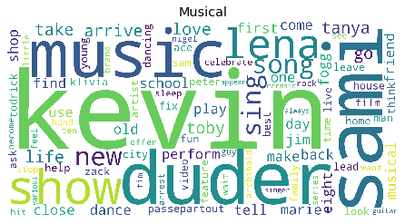

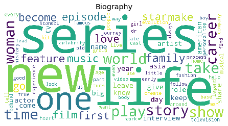

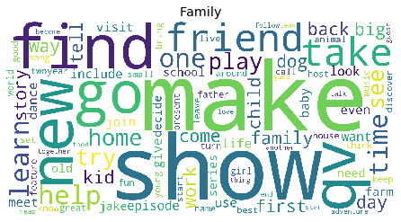

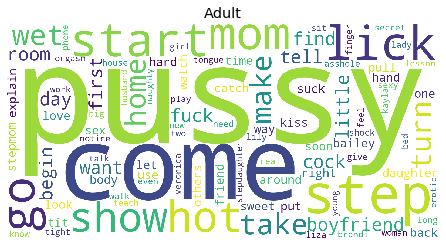

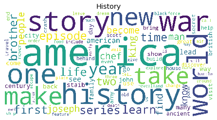

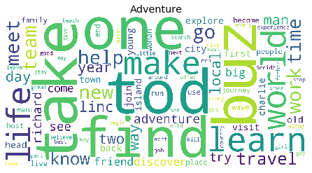

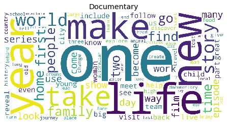

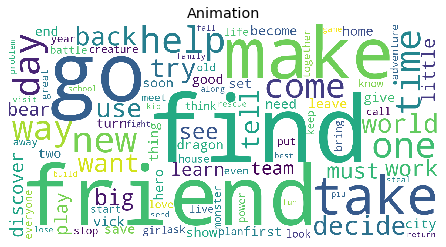

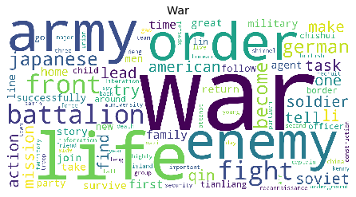

[11 more figures not shown]

```python
from wordcloud import WordCloud

for movie in movie_counts_df['Genre']:
    all_words = get_all_words(movies[movies[movie] == 1]['plot_tokens_cleaned'].tolist())
    fdist = FreqDist(all_words)
    df = pd.DataFrame(fdist.most_common(100),columns=['Word','Count'])
    wordcloud = WordCloud(width = 1600, height = 800,
                background_color ='white',
                min_font_size = 10).generate(df['Word'].to_string())
    plt.title(movie)
    plt.imshow(wordcloud)
    plt.axis("off")
    plt.tight_layout(pad = 0)
    plt.show()
```

# Preparing data for Modeling

```python
# Create a dictionary of data mapped to Genre
data_dict = {}
for movie in movies['Genre'].unique():

    clean_plot_list = []
    for plot_tokens in movies[movies[movie] == 1]['plot_tokens_cleaned'].tolist():
        clean_plot_list += [" ".join(plot_tokens)]

    # Map list of "Cleaned Tokens" and "Sentiment Polarity" to each Genre
    data_dict[movie] = (clean_plot_list, movies['polarity'].tolist())


# Split data set up.
train_data = []
validation_data = []
test_data = []

train_sentiment = []
validation_sentiment = []
test_sentiment = []

Y_train = []
Y_validation = []
Y_test = []

# We will have the training set and the testing set be the same size.
for genre in data_dict:
    # Determine cut length for each genre
    cut = int(len(data_dict[genre][0])//2)
    mid_cut = cut + cut//2
    end_cut = cut + cut

    train_data += data_dict[genre][0][:cut]
    validation_data += data_dict[genre][0][cut:mid_cut]
    test_data += data_dict[genre][0][mid_cut:end_cut]

    train_sentiment += data_dict[genre][1][:cut]
    validation_sentiment += data_dict[genre][1][cut:mid_cut]
    test_sentiment += data_dict[genre][1][mid_cut:end_cut]

    # Grab the Training and Testing data
    Y_train += [genre] * len(data_dict[genre][1][:cut])
    Y_validation += [genre] * len(data_dict[genre][1][cut:mid_cut])
    Y_test += [genre] * len(data_dict[genre][1][mid_cut:end_cut])

# Convert Targets to Series
Y_train = pd.Series(Y_train)
Y_validation = pd.Series(Y_validation)
Y_test = pd.Series(Y_test)

print("Length of Training Set: ", len(train_data))
print("Length of Validation Set: ", len(validation_data))
print("Length of Testing Set: ", len(test_data))
```

```
Length of Training Set:  17492
Length of Validation Set:  8740
Length of Testing Set:  8752
```

# Vectorizing using TfidfVectorizer

`TFIDF` = `Term Frequency - Inverse Document Frequency`

This intends to reflect how imporant a word is to a document. As the word increases in frequency, the tf-idf value increases.

The reason we choose to use this is because "83% of text-based recommender systems in digital libraries use tf-idf" (https://en.wikipedia.org/wiki/Tf%E2%80%93idf).

```python
from sklearn.feature_extraction.text import TfidfVectorizer

vectorizer = TfidfVectorizer(max_features=1000, max_df=0.5, ngram_range=(1,3))
vectorizer.fit(train_data)

# Map indicies to word
inv_map = {v: k for k, v in vectorizer.vocabulary_.items()}

# Transform the Training and Testing data
X_train = vectorizer.transform(train_data).toarray()
X_validation = vectorizer.transform(validation_data).toarray()
X_test = vectorizer.transform(test_data).toarray()

def format_data(X, sentiment):
    """Format data"""
    X = pd.DataFrame(X)
    X = X.rename(columns=inv_map)
    X = pd.concat([X, pd.DataFrame(sentiment)], axis=1)
    X = X.rename(columns={0:"Sentiment Score"})

    return X

X_train = format_data(X_train, train_sentiment)
X_validation = format_data(X_validation, validation_sentiment)
X_test = format_data(X_test, test_sentiment)

# Create a generic form of this, to be used later.
def preprocess_plot(plot_str):
    """Pass in a plot and get out the vectorized form of it"""
    plot_str = remove_noise([plot_str])[0]

    # Get sentiment score
    polarity = TextBlob(plot_str).sentiment.polarity

    # Convert to vectorized form
    vector = vectorizer.transform([plot_str]).toarray()

    # Convert to DataFrame and rename columns
    data = pd.DataFrame(vector)

    data = data.rename(columns=inv_map)

    # Add sentiment score
    data = pd.concat([data, pd.DataFrame(pd.Series(polarity))], axis=1)
    data = data.rename(columns={0:"Sentiment Score"})

    return data
```

```python
X_train.head()
```

|  | 000 | 10 | able | accept | accident | accidentally | accompany | account | accuse | across | act | action | actor | actually | adam | admit | adventure | advice | affair | africa | age | agent | ago | agree | air | al | alex | allow | almost | … |
| --- | --- | --- | --- | --- | --- | --- | --- | --- | --- | --- | --- | --- | --- | --- | --- | --- | --- | --- | --- | --- | --- | --- | --- | --- | --- | --- | --- | --- | --- | --- |
| 0 | 0.0 | 0.0 | 0.0 | 0.0 | 0.0 | 0.0 | 0.0 | 0.0 | 0.0 | 0.218158 | 0.0 | 0.0 | 0.0 | 0.0 | 0.0 | 0.0 | 0.0 | 0.0 | 0.0 | 0.0 | 0.000000 | 0.0 | 0.0 | 0.0 | 0.0 | 0.0 | 0.0 | 0.0 | 0.0 | … |
| 1 | 0.0 | 0.0 | 0.0 | 0.0 | 0.0 | 0.0 | 0.0 | 0.0 | 0.0 | 0.000000 | 0.0 | 0.0 | 0.0 | 0.0 | 0.0 | 0.0 | 0.0 | 0.0 | 0.0 | 0.0 | 0.000000 | 0.0 | 0.0 | 0.0 | 0.0 | 0.0 | 0.0 | 0.0 | 0.0 | … |
| 2 | 0.0 | 0.0 | 0.0 | 0.0 | 0.0 | 0.0 | 0.0 | 0.0 | 0.0 | 0.000000 | 0.0 | 0.0 | 0.0 | 0.0 | 0.0 | 0.0 | 0.0 | 0.0 | 0.0 | 0.0 | 0.000000 | 0.0 | 0.0 | 0.0 | 0.0 | 0.0 | 0.0 | 0.0 | 0.0 | … |
| 3 | 0.0 | 0.0 | 0.0 | 0.0 | 0.0 | 0.0 | 0.0 | 0.0 | 0.0 | 0.000000 | 0.0 | 0.0 | 0.0 | 0.0 | 0.0 | 0.0 | 0.0 | 0.0 | 0.0 | 0.0 | 0.000000 | 0.0 | 0.0 | 0.0 | 0.0 | 0.0 | 0.0 | 0.0 | 0.0 | … |
| 4 | 0.0 | 0.0 | 0.0 | 0.0 | 0.0 | 0.0 | 0.0 | 0.0 | 0.0 | 0.000000 | 0.0 | 0.0 | 0.0 | 0.0 | 0.0 | 0.0 | 0.0 | 0.0 | 0.0 | 0.0 | 0.255744 | 0.0 | 0.0 | 0.0 | 0.0 | 0.0 | 0.0 | 0.0 | 0.0 | … |

```python
Y_train.head()
```

```
0    Comedy
1    Comedy
2    Comedy
3    Comedy
4    Comedy
dtype: object
```

## Test preprocess_plot()

We will test our preprocess_plot() function

```python
preprocess_plot("Hello, my name is Cameron. Also, my group members names are Andrew and Tou. We are excited about this project!")
```

|  | 000 | 10 | able | accept | accident | accidentally | accompany | account | accuse | across | act | action | actor | actually | adam | admit | adventure | advice | affair | africa | age | agent | ago | agree | air | al | alex | allow | almost | … |
| --- | --- | --- | --- | --- | --- | --- | --- | --- | --- | --- | --- | --- | --- | --- | --- | --- | --- | --- | --- | --- | --- | --- | --- | --- | --- | --- | --- | --- | --- | --- |
| 0 | 0.0 | 0.0 | 0.0 | 0.0 | 0.0 | 0.0 | 0.0 | 0.0 | 0.0 | 0.0 | 0.0 | 0.0 | 0.0 | 0.0 | 0.0 | 0.0 | 0.0 | 0.0 | 0.0 | 0.0 | 0.0 | 0.0 | 0.0 | 0.0 | 0.0 | 0.0 | 0.0 | 0.0 | 0.0 | … |

## Sampling Techniques:

Our data is really imbalanced. We will implement some Sampling technqiues to see if this fixes our issues.

- RandomOverSampling
- SMOTE

```python
from imblearn.over_sampling import RandomOverSampler
from imblearn.over_sampling import SMOTE

# RandomOverSampling
ros = RandomOverSampler(random_state=42)
X_ros, y_ros = ros.fit_resample(X_train, Y_train)

# SMOTE
sm = SMOTE(random_state=42)
X_sm, y_sm = sm.fit_resample(X_train, Y_train)
```

# Build Model

The function `test_model` is a generic function that accepts a model, parameters for that model, and data. This function will run the model, and generate an accuracy score and make a prediction.

```python
from sklearn.metrics import accuracy_score

def test_model(model, params, model_name, X_train, y_train, X_test, Y_test, sampling):
    """Trains model, and evaluates it.
        PARAMS:
            model_choice - SKLearn Model: Model to be trained
            params - dictionary: Dictionary of parameters to feed the model
            X_train - DataFrame: Training Data, Features
            y_train - DataFrame: Training Data, Targets
            X_test - DataFrame: Testing Data, Features
            y_test - DataFrame: Testing Data, Targets

        RETURNS:
            Accuracy - float: Accuracy for specified model and parameters.
    """
    print("Begin ", model_name)
    start = time.time()

    # Run model and get predictions and accuracy
    clf = model(**params)
    clf.fit(X_train, y_train)

    predictions = clf.predict(X_test)

    accuracy = accuracy_score(Y_test, predictions)
    print(f"{model_name}, {sampling} -  Accuracy: ", accuracy)

    print("Time Elapsed: ", time.time() - start)

    return (accuracy, clf, model_name, sampling)
```

# Running different models

- KNeighborsClassifier
- Support Vector Machine
- XGBoost

We are running a variety of models to see which one might obtain the best performance.

```python
import xgboost as xgb
from sklearn.svm import SVC
from sklearn.neighbors import KNeighborsClassifier

xgb_params = {'objective':'multi:softmax'}
knc_params = {}
svc_params = {'decision_function_shape':'ovo'}

models_to_test = [
    (KNeighborsClassifier, knc_params, "KNeighbors"),
    (SVC, svc_params, "Support Vector Machine"),
    (xgb.XGBClassifier, xgb_params, "XGBoost")
]
```

```python
results = []

# No Sampling Technique
for model in models_to_test:
        results += [test_model(model[0], model[1], model[2], X_train, Y_train, X_validation, Y_validation, "None")]

# RandomOverSampling
for model in models_to_test:
        results += [test_model(model[0], model[1], model[2], X_ros, y_ros, X_validation, Y_validation, "RandomOverSampling")]

# SMOTE
for model in models_to_test:
        results += [test_model(model[0], model[1], model[2], X_sm, y_sm, X_validation, Y_validation, "SMOTE")]
```

```
Begin  KNeighbors
KNeighbors, None -  Accuracy:  0.40606407322654464
Time Elapsed:  282.5849173069
Begin  Support Vector Machine
Support Vector Machine, None -  Accuracy:  0.5646453089244852
Time Elapsed:  959.5231809616089
Begin  XGBoost
XGBoost, None -  Accuracy:  0.5002288329519451
Time Elapsed:  881.8897895812988
Begin  KNeighbors
KNeighbors, RandomOverSampling -  Accuracy:  0.26933638443935926
Time Elapsed:  2799.7136158943176
Begin  Support Vector Machine
Support Vector Machine, RandomOverSampling -  Accuracy:  0.5673913043478261
Time Elapsed:  2659.0917472839355
Begin  XGBoost
XGBoost, RandomOverSampling -  Accuracy:  0.3236842105263158
Time Elapsed:  4998.648598909378
Begin  KNeighbors
KNeighbors, SMOTE -  Accuracy:  0.15892448512585813
Time Elapsed:  2114.9861340522766
Begin  Support Vector Machine
Support Vector Machine, SMOTE -  Accuracy:  0.5676201372997711
Time Elapsed:  3437.7510776519775
Begin  XGBoost
XGBoost, SMOTE -  Accuracy:  0.3899313501144165
Time Elapsed:  5250.787842512131
```

```python
# Sort results by the best accuracy.
results.sort(key = lambda x: x[0], reverse=True)

print(results)
```

```
[(0.5676201372997711, SVC(C=1.0, break_ties=False, cache_size=200, class_weight=None, coef0=0.0,
    decision_function_shape='ovo', degree=3, gamma='scale', kernel='rbf',
    max_iter=-1, probability=False, random_state=None, shrinking=True,
    tol=0.001, verbose=False), 'Support Vector Machine', 'SMOTE'), (0.5673913043478261, SVC(C=1.0, break_ties=False, cache_size=200, class_weight=None, coef0=0.0,
    decision_function_shape='ovo', degree=3, gamma='scale', kernel='rbf',
    max_iter=-1, probability=False, random_state=None, shrinking=True,
    tol=0.001, verbose=False), 'Support Vector Machine', 'RandomOverSampling'), (0.5646453089244852, SVC(C=1.0, break_ties=False, cache_size=200, class_weight=None, coef0=0.0,
    decision_function_shape='ovo', degree=3, gamma='scale', kernel='rbf',
    max_iter=-1, probability=False, random_state=None, shrinking=True,
    tol=0.001, verbose=False), 'Support Vector Machine', 'None'), (0.5002288329519451, XGBClassifier(base_score=0.5, booster='gbtree', colsample_bylevel=1,
              colsample_bynode=1, colsample_bytree=1, gamma=0,
              learning_rate=0.1, max_delta_step=0, max_depth=3,
              min_child_weight=1, missing=None, n_estimators=100, n_jobs=1,
              nthread=None, objective='multi:softprob', random_state=0,
              reg_alpha=0, reg_lambda=1, scale_pos_weight=1, seed=None,
              silent=None, subsample=1, verbosity=1), 'XGBoost', 'None'), (0.40606407322654464, KNeighborsClassifier(algorithm='auto', leaf_size=30, metric='minkowski',
                     metric_params=None, n_jobs=None, n_neighbors=5, p=2,
                     weights='uniform'), 'KNeighbors', 'None'), (0.3899313501144165, XGBClassifier(base_score=0.5, booster='gbtree', colsample_bylevel=1,
              colsample_bynode=1, colsample_bytree=1, gamma=0,
              learning_rate=0.1, max_delta_step=0, max_depth=3,
              min_child_weight=1, missing=None, n_estimators=100, n_jobs=1,
              nthread=None, objective='multi:softprob', random_state=0,
              reg_alpha=0, reg_lambda=1, scale_pos_weight=1, seed=None,
              silent=None, subsample=1, verbosity=1), 'XGBoost', 'SMOTE'), (0.3236842105263158, XGBClassifier(base_score=0.5, booster='gbtree', colsample_bylevel=1,
              colsample_bynode=1, colsample_bytree=1, gamma=0,
              learning_rate=0.1, max_delta_step=0, max_depth=3,
              min_child_weight=1, missing=None, n_estimators=100, n_jobs=1,
              nthread=None, objective='multi:softprob', random_state=0,
              reg_alpha=0, reg_lambda=1, scale_pos_weight=1, seed=None,
              silent=None, subsample=1, verbosity=1), 'XGBoost', 'RandomOverSampling'), (0.26933638443935926, KNeighborsClassifier(algorithm='auto', leaf_size=30, metric='minkowski',
                     metric_params=None, n_jobs=None, n_neighbors=5, p=2,
                     weights='uniform'), 'KNeighbors', 'RandomOverSampling'), (0.15892448512585813, KNeighborsClassifier(algorithm='auto', leaf_size=30, metric='minkowski',
                     metric_params=None, n_jobs=None, n_neighbors=5, p=2,
                     weights='uniform'), 'KNeighbors', 'SMOTE')]
```

# Metrics for Choosing the Best Classifier.

First we will see which model performed the best. We will evaluate this just based on pure `accuracy`. Although, this may not be the best metric to use in a multi-classification, with balance issues, it will suffice for simple model selection.

## Test our Classifer on Testing Set

Once we test our model on the Testing Set, we will see some metrics within each class, and then some metrics for the entire model. This is done using the handy `classification_report` method within sklearn.

Precision

- `True Postive / Actual Results`

Recall

- `True Postive / Predicted Results`

F1-Score

- The F1-Score is a Harmonic mean between the Precision and Recall. This can be calculated as follows:
  - `2 * (Precision * Recall) / (Precision + Recall)`

Support

- The number of samples matching that class in the `actual` predictions set.

Accuracy

- `(True Postive + True Negative) / Actual Results`

```python
from sklearn.metrics import classification_report

# Grab best CLF
best_clf = results[0][1]
print("The best classifier was: ", results[0][2], ". With a ", results[0][0], "% accuracy on the validation set.")

# Best predictions on testing set
predictions = best_clf.predict(X_test)

print(classification_report(Y_test, predictions))
```

```
The best classifier was:  Support Vector Machine . With a  0.5676201372997711 % accuracy on the validation set.
              precision    recall  f1-score   support

      Action       0.00      0.00      0.00        50
       Adult       0.00      0.00      0.00        13
   Adventure       0.32      0.03      0.06       176
   Animation       0.53      0.20      0.29       414
   Biography       0.00      0.00      0.00        41
      Comedy       0.51      0.82      0.63      2731
       Crime       0.50      0.14      0.22       159
 Documentary       0.56      0.70      0.62      1523
       Drama       0.54      0.44      0.49      1864
      Family       0.37      0.08      0.13       401
     Fantasy       0.00      0.00      0.00        32
     History       0.00      0.00      0.00        73
      Horror       0.00      0.00      0.00        66
       Music       0.43      0.26      0.32       185
     Musical       0.00      0.00      0.00         9
     Mystery       0.00      0.00      0.00        60
     Romance       0.89      0.50      0.64       131
      Sci-Fi       0.29      0.02      0.04        94
       Short       0.00      0.00      0.00        18
       Sport       0.64      0.25      0.36       173
    Thriller       0.00      0.00      0.00        44
         War       0.00      0.00      0.00         7
     Western       0.83      0.66      0.74       488

    accuracy                           0.54      8752
   macro avg       0.28      0.18      0.20      8752
weighted avg       0.52      0.54      0.50      8752
```

# New predictions

```python
# Make list of movies to predict for
custom_plot_lst = [

    # Cameron Picked some Random Movies and Shows
    ("Tiger King", ['Documentary', 'Crime'],"A rivalry between big cat eccentrics takes a dark turn when Joe Exotic, a controversial animal park boss, is caught in a murder-for-hire plot."),
    ("Step Brothers", ['Comedy'], "Two aimless middle-aged losers still living at home are forced against their will to become roommates when their parents marry."),
    ("Parks and Recreation", ['Comedy'], "The absurd antics of an Indiana town's public officials as they pursue sundry projects to make their city a better place."),
    ("Star Wars", ['Action', 'Adventure', 'Fantasy'], "The surviving members of the resistance face the First Order once again, and the legendary conflict between the Jedi and the Sith reaches its peak bringing the Skywalker saga to its end."),
    ("The Notebook", ['Drama','Romance'],"A poor yet passionate young man falls in love with a rich young woman, giving her a sense of freedom, but they are soon separated because of their social differences."),
    ("Schindler's List", ['Biography','Drama', 'History'],"In German-occupied Poland during World War II, industrialist Oskar Schindler gradually becomes concerned for his Jewish workforce after witnessing their persecution by the Nazis."),

    # Cameron asked his family what their favorite movies were

    # Dad's
    ("A Few Good Men", ['Drama', 'Thriller'], "Military lawyer Lieutenant Daniel Kaffee defends Marines accused of murder. They contend they were acting under orders."),
    ("Annie Hall", ['Comedy', 'Romance'], "Neurotic New York comedian Alvy Singer falls in love with the ditzy Annie Hall."),
    ("Defending Your Life", ['Comedy', 'Drama', 'Fantasy'], "Daniel Miller (Albert Brooks) isn't having a good week. For starters, he died after he got hit by a bus. Then he discovers that in the afterlife he must defend his actions on Earth in order to ascend to a higher plane of existence. While awaiting judgment, he falls in love with Julia (Meryl Streep), whose near-perfect life on Earth seemingly makes her a shoe-in for ascension. However, Daniel's actions in his lifetime might not be enough for him to move on."),

    # Mom's Movies
    ("My Cousin Vinny", ['Comedy', 'Crime'], "Two New Yorkers are accused of murder in rural Alabama while on their way back to college, and one of their cousins--an inexperienced, loudmouth lawyer not accustomed to Southern rules and manners--comes in to defend them."),
    ("Moonstruck", ['Comedy', 'Drama', 'Romance'], "Loretta Castorini, a bookkeeper from Brooklyn, New York, finds herself in a difficult situation when she falls for the brother of the man she has agreed to marry."),
    ("Its a Wonderful Life", ['Drama', 'Family', 'Fantasy'], "An angel is sent from Heaven to help a desperately frustrated businessman by showing him what life would have been like if he had never existed."),

    # Sister's Movies
    ("Pans Labryinth", ['Drama', 'Fantasy', 'War'], "In the Falangist Spain of 1944, the bookish young stepdaughter of a sadistic army officer escapes into an eerie but captivating fantasy world."),
    ("The Big Lebowski", ['Comedy', 'Crime', 'Sport'], "Jeff 'The Dude' Lebowski, mistaken for a millionaire of the same name, seeks restitution for his ruined rug and enlists his bowling buddies to help get it."),
    ("Apocalypse Now", ['Drama', 'Mystery', 'War'], "A U.S. Army officer serving in Vietnam is tasked with assassinating a renegade Special Forces Colonel who sees himself as a god."),
    ("Easy Rider" , ['Adventure', 'Drama'], "Two bikers head from L.A. to New Orleans through the open country and desert lands, and along the way they meet a man who bridges a counter-culture gap they are unaware of."),
    ("Parasite", ['Comedy', 'Drama', 'Thriller'], "Greed and class discrimination threaten the newly formed symbiotic relationship between the wealthy Park family and the destitute Kim clan."),
    ("There Will Be Blood", ['Drama'], "A story of family, religion, hatred, oil and madness, focusing on a turn-of-the-century prospector in the early days of the business."),
    ("The Texas Chainsaw Massacre", ['Horror'], "After picking up a traumatized young hitchhiker, five friends find themselves stalked and hunted by a deformed chainsaw-wielding loon and his family of equally psychopathic killers."),
    ("Alien", ['Horror', 'Sci-Fi'], "After a space merchant vessel receives an unknown transmission as a distress call, one of the crew is attacked by a mysterious life form and they soon realize that its life cycle has merely begun."),
]
```

```python
def make_single_prediction(plot_str, clf):
    """Pass in a String and model, and make a prediction on it."""
    data = preprocess_plot(plot_str)

    return clf.predict(data)[0]

correct = 0
for custom_plot in custom_plot_lst:
        prediction = make_single_prediction(custom_plot[2], best_clf)

        print("Film: ", custom_plot[0])
        print("\tPredicted Genre: ", prediction)
        print("\tAcceptable Answers: ", ",".join(custom_plot[1]))
        print("\n")

        correct += prediction in custom_plot[1]

print("Accuracy: ", correct/len(custom_plot_lst))
```

```
Film:  Tiger King
	Predicted Genre:  Crime
	Acceptable Answers:  Documentary,Crime


Film:  Step Brothers
	Predicted Genre:  Comedy
	Acceptable Answers:  Comedy


Film:  Parks and Recreation
	Predicted Genre:  Documentary
	Acceptable Answers:  Comedy


Film:  Star Wars
	Predicted Genre:  Comedy
	Acceptable Answers:  Action,Adventure,Fantasy


Film:  The Notebook
	Predicted Genre:  Drama
	Acceptable Answers:  Drama,Romance


Film:  Schindler's List
	Predicted Genre:  Documentary
	Acceptable Answers:  Biography,Drama,History


Film:  A Few Good Men
	Predicted Genre:  Drama
	Acceptable Answers:  Drama,Thriller


Film:  Annie Hall
	Predicted Genre:  Comedy
	Acceptable Answers:  Comedy,Romance


```

[output cut: 46 more lines]

```
	Predicted Genre:  Documentary
	Acceptable Answers:  Drama


Film:  The Texas Chainsaw Massacre
	Predicted Genre:  Documentary
	Acceptable Answers:  Horror


Film:  Alien
	Predicted Genre:  Comedy
	Acceptable Answers:  Horror,Sci-Fi


Accuracy:  0.5
```

# Results

Given a plot for a particular movie, we are able to predict which genre the plot corresponds to ~50% of the time. This can be seen by the following results:

- Validation Data: 57%
- Testing Data: 54%
- Cameron's Data: 50%

These results are quite good considering we have 23 different Genres we are predicting for. If we were attempting to randomly pick a genre each time, we would expect a ~4% (1/23) accuracy. This shows us that our classifier is able to classify genres with a prediction accuracy that is better than random.

The classifer we used was a Support Vector Machine that passed in resampled data (using SMOTE). We compared the performance of the SVM to KNN and XGBoost models, and the SVM consistently outperformed both of the other two models.

# Conclusion

Our main goal in this project was to be able to predict a movie's genre based on the movie's plot.

With this in mind, the data that we analyzed was pulled down from IMDb that contained the following information:

- Title
- Plot
- Genre

We first cleaned up our dataset, by removing data that was not needed, such as movies in different languages, genres with no movies linked to them, and more. We then were able to transform the plots of each movie into a set of cleaned tokens that represented the most important words. This would then allows us to further transformed those tokens using the TF-DIF vectorizer which converts tokens to their relative frequency count within the document and shows us how important the token is. Finally, we calculated the sentiment score for each plot in order to find the positive-negative polarity rating of each plot.

Once all of the data was prepared and cleaned, we built mulltiple models to test our data that could adequately predict the Genre of a movie based on its plot. We tested our data with 3 different models: SVM, KNN, and XGBoost. Each model ended up with varying degrees of accuracy, with SVM being the most accurate.

In conclusion, we ended with our best model, SVM, having an accuracy of `54%`.